# Statistical Inference Course Project Part2

Naqeeb Asif

14 February 2018

# Synopsis

This experiment explores the ToothGrowth data set. Exploratory analysis is first performed on the dataset. After the analysis the hypothesis test is performed according to which “dose” is the most significant in predicting the “length”.

# Loading the data

In this section “Tooth Growth” data is loaded.

```r
data("ToothGrowth")
head(ToothGrowth)
```

```
##    len supp dose
## 1  4.2   VC  0.5
## 2 11.5   VC  0.5
## 3  7.3   VC  0.5
## 4  5.8   VC  0.5
## 5  6.4   VC  0.5
## 6 10.0   VC  0.5
```

# Exploratoty analysis

In this section exploratory analysis is performed on the data

## Checking the structure of the data

```r
str(ToothGrowth)
```

```
## 'data.frame':    60 obs. of  3 variables:
##  $ len : num  4.2 11.5 7.3 5.8 6.4 10 11.2 11.2 5.2 7 ...
##  $ supp: Factor w/ 2 levels "OJ","VC": 2 2 2 2 2 2 2 2 2 2 ...
##  $ dose: num  0.5 0.5 0.5 0.5 0.5 0.5 0.5 0.5 0.5 0.5 ...
```

## Checking the unique entries in feature ‘dose’

```r
unique(ToothGrowth$dose)
```

```
## [1] 0.5 1.0 2.0
```

As there are only three unique values in this feature so lets change the calss of the this feature to factor.

```r
ToothGrowth$dose <- factor(ToothGrowth$dose)
```

## Boxplot of features

In this section boxplot is plotted between different features of the data.

### Boxplot between ‘Suppliment type’ and ‘length’

In this section boxplot is plotted between length of tooth and supplement type.

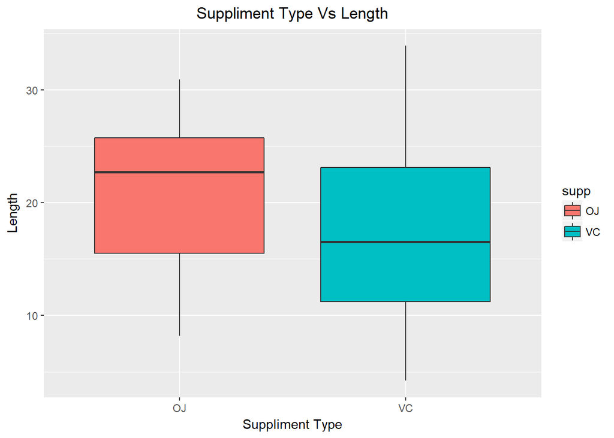

```r
library(ggplot2)
g <- ggplot(data = ToothGrowth,aes(supp,len))
g + geom_boxplot(aes(fill=supp)) +
  labs(title="Suppliment Type Vs Length")+
  theme(plot.title = element_text(hjust = 0.5))+
  xlab("Suppliment Type")+ylab("Length")
```

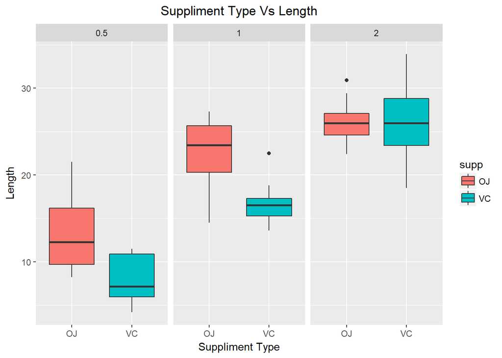

```r
library(ggplot2)
g <- ggplot(data = ToothGrowth,aes(supp,len))
g + geom_boxplot(aes(fill=supp)) +facet_grid(.~dose)+
  labs(title="Suppliment Type Vs Length")+
  theme(plot.title = element_text(hjust = 0.5))+
  xlab("Suppliment Type")+ylab("Length")
```

### Boxplot between Dose and length

In this section boxplot is plotted between length of tooth and dose.

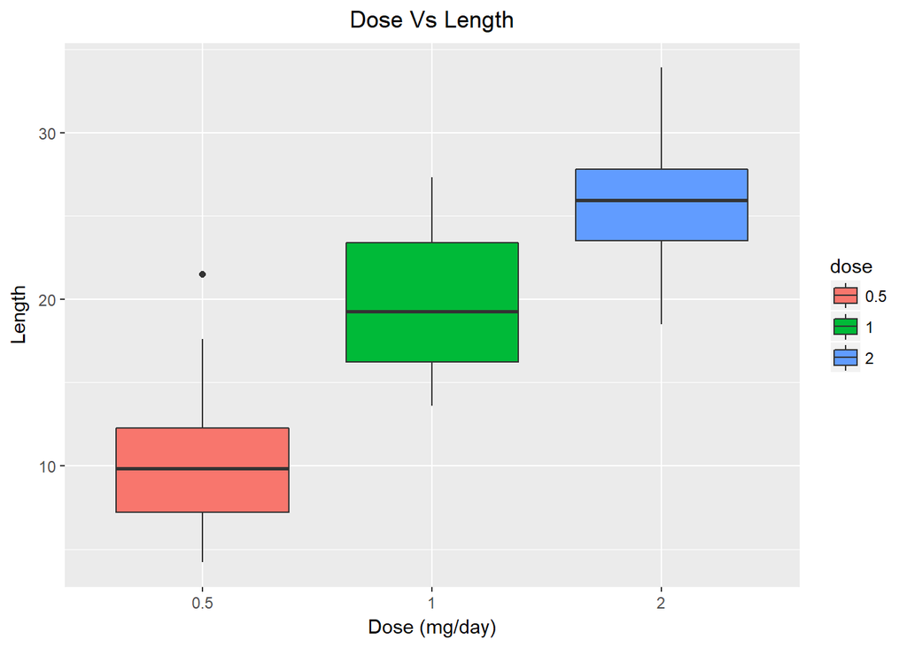

```r
library(ggplot2)
g <- ggplot(data = ToothGrowth,aes(dose,len))
g + geom_boxplot(aes(fill=dose))+
  labs(title="Dose Vs Length")+
  theme(plot.title = element_text(hjust = 0.5))+
  xlab("Dose (mg/day)")+ylab("Length")
```

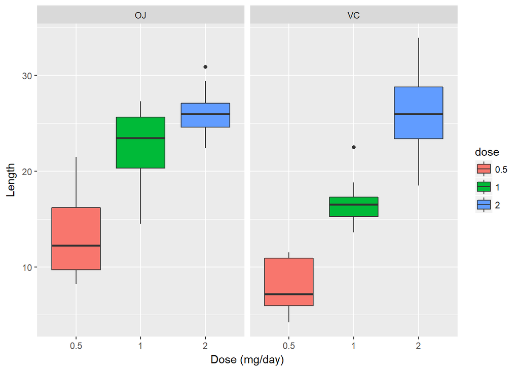

```r
library(ggplot2)
g <- ggplot(data = ToothGrowth,aes(dose,len))
g + geom_boxplot(aes(fill=dose)) + facet_grid(.~supp)+
  xlab("Dose (mg/day)")+ylab("Length")
```

## Results

As it can be seen from the plots that length depends upon the dose and suppliment. Each supllement type has different mean according to its type. Same is the case with different doeses.